# Particle channel: final story for thesis

First plot the ACF/SF

```r
x=c(1:255)
xSF=x*640.17/512
L <- 640.17
pixel_to_micron <- 2*pi/L

#example SF plots (particle channel)
bijelSF_l <- unlist(read.csv("/Volumes/PhD/BijelData/SF_bothChannels/52ii_Image23.tif_radProf_channel1.txt"))
noBijelSF_l <- unlist(read.csv("/Volumes/PhD/BijelData/SF_bothChannels/54i_Image9.tif_radProf_channel1.txt"))
png('~/Desktop/bijels2_graphs/SFexamples_part.png', res=300, width=1800, height=1200)
plot(xSF, bijelSF_l, type="l", lwd=2, col="red", xlab = "q (1/μm)", ylab="Structure Factor", ylim=c(0.4,2.2),cex.axis=1.5,cex.lab=2,mgp=c(2.2,0.7,0))
lines(xSF, noBijelSF_l, lwd=2)
legend("topright", legend = c("Bijel", "Non-bijel"), col=c("red", "black"), lwd=2)#, cex=1.4)
dev.off()
```

```r
#example ACF plots (particle channel)
bijelACF_l <- unlist(read.csv("/Volumes/PhD/BijelData/ParticleChannel/autoCorr/52ii_Image23.tif_autoCorr_channel1.txt"))
noBijelACF_l <- unlist(read.csv("/Volumes/PhD/BijelData/ParticleChannel/autoCorr/54i_Image9.tif_autoCorr_channel1.txt"))
x=c(1:255)
xACF=x*pixel_to_micron
png('~/Desktop/bijels2_graphs/ACFexamples_part.png', res=300, width=1800, height=1200)
plot(xACF, bijelACF_l, type="l", lwd=2, col="red", xlab = "r (μm)", ylab="Autocorrelation Function",cex.axis=1.5,cex.lab=2,mgp=c(2.2,0.7,0), ylim=c(0.9, 1))
lines(xACF, noBijelACF_l, lwd=2)
legend("topright", legend = c("Bijel", "Non-bijel"), col=c("red", "black"), lwd=2)
dev.off()
```

Next read in all the data:

```r
library(pastecs)


corrFiles <- list.files("/Volumes/PhD/BijelData/ParticleChannel/autoCorr", pattern=".txt", full.names = TRUE)
corrFileNames <- list.files("/Volumes/PhD/BijelData/ParticleChannel/autoCorr", pattern=".txt")

autoCorr <- do.call(cbind, lapply(corrFiles, read.csv, header=FALSE))
colnames(autoCorr) <- corrFileNames

exp_Data <- read.csv("/Volumes/PhD/BijelData/Bijel_Data_Cleaner_ToRead.csv", na.strings = "?")
exp_Data$Sample.Number <- as.character(exp_Data$Sample.Number)

corrFileID <- sapply(strsplit(corrFileNames,"_"), `[`,1) #`[` is a function that takes the subset of x, the input to this function is x (strsplit...) and the element of x that I want, ie the 1st one
colnames(autoCorr) <- corrFileID

rownames(exp_Data) <- exp_Data$Sample.Number
autoCorr_transpose <- data.frame(t(autoCorr))
exp_Data$Autocorrelation <- autoCorr_transpose[match(row.names(exp_Data),row.names(autoCorr_transpose)),c(1:256)]


radFiles <- list.files("/Volumes/PhD/BijelData/ParticleChannel/radProf", pattern=".txt", full.names = TRUE)
radFileNames <- list.files("/Volumes/PhD/BijelData/ParticleChannel/radProf", pattern=".txt")

radProf_data <- do.call(cbind, lapply(radFiles, read.csv, header=FALSE))
colnames(radProf_data) <- radFileNames

radFileID <- sapply(strsplit(radFileNames,"_"), `[`,1) #`[` is a function that takes the subset of x, the input to this function is x (strsplit...) and the element of x that I want, ie the 1st one
colnames(radProf_data) <- radFileID

rownames(exp_Data) <- exp_Data$Sample.Number
radProf_data_transpose <- data.frame(t(radProf_data))
exp_Data$Radial.Profile <- radProf_data_transpose[match(row.names(exp_Data),row.names(radProf_data_transpose)),c(1:256)]
```

Autocorrelation variables: * gradient at start (try 1-10 and 1-20) * x position of first turning point * y position of first turning point * number of turning points

```r
library(ggplot2)

turningPoints <- lapply(1:135, function(y) turnpoints(unlist(exp_Data$Autocorrelation[y,])))
firstTurn <- lapply(1:135, function(y) turningPoints[[y]]$tppos[1])
exp_Data$Auto.First.Turn.Pos <- unlist(firstTurn)



exp_Data$Auto.First.Turn.Val <- unlist(lapply(1:135, function(y) exp_Data$Autocorrelation[y,exp_Data$Auto.First.Turn[y]]))



exp_Data$Auto.Num.Turns <- unlist(lapply(1:135, function(y) length(turningPoints[[y]]$tppos)))



r <- c(1:256)
y <- exp_Data$Autocorrelation[1:20]
lineFits <- lapply(1:135, function(n) lm(unlist(y[n,]) ~ r[1:20]))
lineCoeffs <- lapply(lineFits, function(m) m$coefficients)
lineGradients <- lapply (1:135, function(p) unname(lineCoeffs[[p]][2]))
exp_Data$Line.Gradients.20 <- unlist(lineGradients)



y2 <- exp_Data$Autocorrelation[1:10]
lineFits2 <- lapply(1:135, function(n) lm(unlist(y2[n,]) ~ r[1:10]))
lineCoeffs2 <- lapply(lineFits2, function(m) m$coefficients)
lineGradients2 <- lapply (1:135, function(p) unname(lineCoeffs2[[p]][2]))
exp_Data$Line.Gradients.10 <- unlist(lineGradients2)
```

Plot them:

```r
head(exp_Data)
```

|  | Sample.Number | Date.Made | HMDS..g | HMDS.Ratio | Ammonia..g | Nitromethane | Ethanediol | Particles | Nitromethane.mass.fraction | Particle.Volume.Fraction... | Particle.Batch | Quench.Method | Bubbles | Droplets | Excess.Particles | Bijel | Autocorrelation | Radial.Profile | Auto.First.Turn.Pos | Auto.First.Turn.Val | Auto.Num.Turns | Line.Gradients.20 | Line.Gradients.10 |
| --- | --- | --- | --- | --- | --- | --- | --- | --- | --- | --- | --- | --- | --- | --- | --- | --- | --- | --- | --- | --- | --- | --- | --- |
| 52i | 52i | 02/05/2014 | 0.1046 | 0.958 | 0.7001 | 0.6823 | 0.3850 | 0.0923 | 0.6392767 | 5.114468 | 2 | Stirred Water Bath | NA | NM | ED | y |  |  | 141 | 0.8721255 | 21 | -0.004054810 | -0.006330919 |
| 52ii | 52ii | 02/05/2014 | 0.1046 | 0.958 | 0.7001 | 0.6823 | 0.3850 | 0.0923 | 0.6392767 | 5.114468 | 2 | Stirred Water Bath | NA | NM | ED | y |  |  | 25 | 0.9427499 | 79 | -0.002797455 | -0.004547129 |
| 53i | 53i | 02/05/2014 | 0.1132 | 0.886 | 0.6894 | 0.6811 | 0.3918 | 0.0903 | 0.6348215 | 4.984090 | 2 | Stirred Water Bath | NA | None | None | y |  |  | 54 | 0.9250112 | 75 | -0.003172371 | -0.006116804 |
| 53ii | 53ii | 02/05/2014 | 0.1132 | 0.886 | 0.6894 | 0.6811 | 0.3918 | 0.0903 | 0.6348215 | 4.984090 | 2 | Stirred Water Bath | NA | ED | NM | y |  |  | 65 | 0.9294203 | 75 | -0.003089188 | -0.004436204 |
| 54i | 54i | 14/05/2014 | 0.1060 | 0.954 | 0.7120 | 0.6892 | 0.3987 | 0.0918 | 0.6335141 | 4.996297 | 2 | Stirred Water Bath | NA | NM | ED | n |  |  | 99 | 0.9053467 | 95 | -0.003108136 | -0.004045131 |
| 54ii | 54ii | 14/05/2014 | 0.1060 | 0.954 | 0.7120 | 0.6892 | 0.3987 | 0.0918 | 0.6335141 | 4.996297 | 2 | Stirred Water Bath | NA | NM | ED | y |  |  | 124 | 0.9283212 | 79 | -0.002008915 | -0.003207002 |

```r
png(file='/Users/s1101153/Desktop/bijels2_graphs/bjp_auto-first-turn-pos.png', width=600, height=400)
ggplot(exp_Data, aes(x=as.factor(Bijel), y=Auto.First.Turn.Pos, fill=Bijel)) + geom_boxplot(alpha=0.3) + geom_jitter(alpha=0.5) + xlab("Bijel?") + ylab("Turning point position") + ggtitle("ACF Position of first turning point")+theme(legend.position="none", text = element_text(size=24), axis.title = element_text(size=21))
dev.off()
```

```r
png(file='/Users/s1101153/Desktop/bijels2_graphs/bjp_auto-first-turn-val.png', width=600, height=400)
ggplot(exp_Data, aes(x=as.factor(Bijel), y=Auto.First.Turn.Val, fill=Bijel)) + geom_boxplot(alpha=0.3) + geom_jitter(alpha=0.5) + xlab("Bijel?") + ylab("Turning point value") + ggtitle("Value of ACF at first turning point")+theme(legend.position="none", text = element_text(size=24), axis.title = element_text(size=21))
dev.off()
```

```r
png(file='/Users/s1101153/Desktop/bijels2_graphs/bjp_auto-num-turns.png', width=600, height=400)
ggplot(exp_Data, aes(x=as.factor(Bijel), y=Auto.Num.Turns, fill=Bijel)) + geom_boxplot(alpha=0.3) + geom_jitter(alpha=0.5) + xlab("Bijel?") + ylab("Number of turning points") + ggtitle("Number of turning points in ACF")+theme(legend.position="none", text = element_text(size=24), axis.title = element_text(size=21))
dev.off()
```

```r
png(file='/Users/s1101153/Desktop/bijels2_graphs/bjp_line-gradients-20.png', width=600, height=400)
ggplot(exp_Data, aes(x=as.factor(Bijel), y=Line.Gradients.20, fill=Bijel)) + geom_boxplot(alpha=0.3) + geom_jitter(alpha=0.5) + xlab("Bijel?") + ylab("Gradient") + ggtitle("Gradient of first 20 points of ACF")+theme(legend.position="none", text = element_text(size=24), axis.title = element_text(size=21))
dev.off()
```

```r
png(file='/Users/s1101153/Desktop/bijels2_graphs/bjp_line-gradients-10.png', width=600, height=400)
ggplot(exp_Data, aes(x=as.factor(Bijel), y=Line.Gradients.10, fill=Bijel)) + geom_boxplot(alpha=0.3) + geom_jitter(alpha=0.5) + xlab("Bijel?") + ylab("Gradient") + ggtitle("Gradient of first 10 points of ACF")+theme(legend.position="none", text = element_text(size=24), axis.title = element_text(size=21))
dev.off()
```

Now scale the data for accurate results:

```r
attach(exp_Data)
dat=data.frame(Line.Gradients.10, Line.Gradients.20, Auto.Num.Turns, Auto.First.Turn.Val, Auto.First.Turn.Pos)

means = unlist(lapply(1:5, function(n) mean(unlist(dat[n][]))))

#datScaled = data.frame(lapply(1:5, function(n) dat[n][]*means[1]/means[n]*1000))
means = unlist(lapply(1:5, function(n) mean(unlist(dat[n]))))
stdevs = unlist(lapply(1:5, function(n) sd(unlist(dat[n]))))
datScaled = data.frame(lapply(1:5, function(n) (dat[n]-means[n])/stdevs[n]))
datScaled$Bijel = Bijel
head(datScaled)
```

|  | Line.Gradients.10 | Line.Gradients.20 | Auto.Num.Turns | Auto.First.Turn.Val | Auto.First.Turn.Pos | Bijel |
| --- | --- | --- | --- | --- | --- | --- |
| 1 | 0.4155941 | 0.2740060 | -3.1473675 | -0.1654015 | 2.19175537 | y |
| 2 | 0.8232903 | 0.8026824 | 0.0283912 | 1.0643704 | -1.05851822 | y |
| 3 | 0.4645314 | 0.6450426 | -0.1906266 | 0.7554882 | -0.24594982 | y |
| 4 | 0.8486428 | 0.6800186 | -0.1906266 | 0.8322631 | 0.06226578 | y |
| 5 | 0.9380250 | 0.6720513 | 0.9044626 | 0.4130734 | 1.01493218 | n |
| 6 | 1.1295845 | 1.1342377 | 0.0283912 | 0.8131254 | 1.71542217 | y |

Now run decision tree

```r
library(caret)
```

```r
library(rpart.plot)
set.seed(1234)

trCtrl <- trainControl(method="repeatedcv", number=10, repeats = 3)
dtreeFit <- train(Bijel ~., data=datScaled, method="rpart", parms=list(split="gini"), trControl=trCtrl, tuneLength=10)

dtreeFit
```

```
## CART
##
## 135 samples
##   5 predictor
##   2 classes: 'n', 'y'
##
## No pre-processing
## Resampling: Cross-Validated (10 fold, repeated 3 times)
## Summary of sample sizes: 122, 122, 122, 121, 122, 121, ...
## Resampling results across tuning parameters:
##
##   cp          Accuracy   Kappa
##   0.00000000  0.7050183  0.29416050
##   0.01291990  0.7050183  0.29416050
##   0.02583979  0.7048352  0.28761029
##   0.03875969  0.7024542  0.27880304
##   0.05167959  0.6998901  0.26827672
##   0.06459948  0.6722344  0.18568573
##   0.07751938  0.6925397  0.20526181
##   0.09043928  0.7188034  0.23075412
##   0.10335917  0.7111111  0.16833446
##   0.11627907  0.6741148  0.01485159
##
## Accuracy was used to select the optimal model using the largest value.
## The final value used for the model was cp = 0.09043928.
```

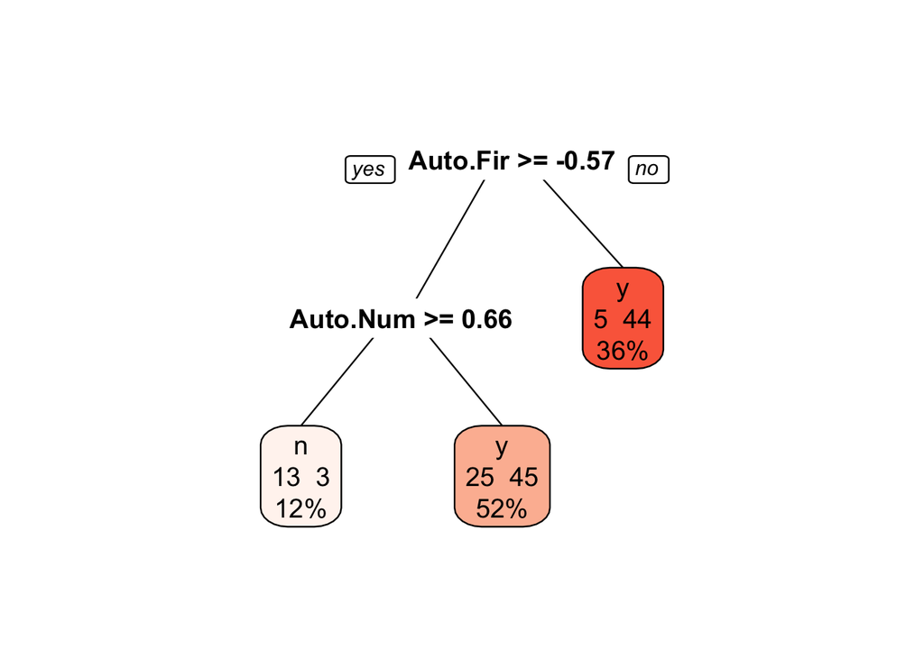

```r
prp(dtreeFit$finalModel, box.palette = "Reds", tweak=1.2, extra=101)
```

```r
# table(Predict=dtreeFit$pred(datScaled), true=Bijel)
```

Now knn:

```r
set.seed(1234)
knn_fit <- train(Bijel ~., data=datScaled, method="knn", trControl=trCtrl, tuneLength=42)

knn_fit
```

```
## k-Nearest Neighbors
##
## 135 samples
##   5 predictor
##   2 classes: 'n', 'y'
##
## No pre-processing
## Resampling: Cross-Validated (10 fold, repeated 3 times)
## Summary of sample sizes: 122, 122, 122, 121, 122, 121, ...
## Resampling results across tuning parameters:
##
##   k   Accuracy   Kappa
##    5  0.7563736  0.381224591
##    7  0.7563736  0.376859702
##    9  0.7539438  0.361031338
```

[output cut: 42 more lines]

Logistic regression:

```r
set.seed(1234)
logRegFit <- train(Bijel ~., data=datScaled, method="glm", trControl=trCtrl)
logRegFit
```

```
## Generalized Linear Model
##
## 135 samples
##   5 predictor
##   2 classes: 'n', 'y'
##
## No pre-processing
## Resampling: Cross-Validated (10 fold, repeated 3 times)
## Summary of sample sizes: 122, 122, 122, 121, 122, 121, ...
## Resampling results:
##
##   Accuracy   Kappa
##   0.7972894  0.5129982
```

SVM:

```r
set.seed(1234)
svmFit <- train(Bijel~., data=datScaled, method="svmLinear", trControl=trCtrl, tuneLength=10)
svmFit
```

```
## Support Vector Machines with Linear Kernel
##
## 135 samples
##   5 predictor
##   2 classes: 'n', 'y'
##
## No pre-processing
## Resampling: Cross-Validated (10 fold, repeated 3 times)
## Summary of sample sizes: 122, 122, 122, 121, 122, 121, ...
## Resampling results:
##
##   Accuracy   Kappa
##   0.7846276  0.4496696
##
## Tuning parameter 'C' was held constant at a value of 1
```

Compare all the errors:

```r
error_dtree = 1-dtreeFit$results[row.names(knn_fit$bestTune),]$Accuracy
paste0('Decision tree error: ', error_dtree)
```

```
## [1] "Decision tree error: 0.294981684981685"
```

```r
error_knn = 1-knn_fit$results[row.names(knn_fit$bestTune),]$Accuracy
paste0('KNN error: ', error_knn)
```

```
## [1] "KNN error: 0.243626373626374"
```

```r
error_logreg = 1-logRegFit$results$Accuracy
paste0('Logistic regression error: ', error_logreg)
```

```
## [1] "Logistic regression error: 0.202710622710623"
```

```r
error_svm = 1-svmFit$results$Accuracy
paste0('SVM error: ', error_svm)
```

```
## [1] "SVM error: 0.215372405372405"
```

Logistic regression has best performance and also has benefits over SVM, the next best option. Look in detail at this result.

```r
logRegFit$finalModel$coefficients
```

```
##         (Intercept)   Line.Gradients.10   Line.Gradients.20
##           1.6527222          -6.6209507           5.5807120
##      Auto.Num.Turns Auto.First.Turn.Val Auto.First.Turn.Pos
##          -0.5361290           0.1875199          -0.3741451
```

```r
exp(logRegFit$finalModel$coefficients)
```

```
##         (Intercept)   Line.Gradients.10   Line.Gradients.20
##        5.221173e+00        1.332164e-03        2.652604e+02
##      Auto.Num.Turns Auto.First.Turn.Val Auto.First.Turn.Pos
##        5.850084e-01        1.206254e+00        6.878771e-01
```

Calculate effect of removing each variable

```r
errors <- rep(NA, 5)
set.seed(1234)
logRegFit5 <- train(Bijel ~., data=datScaled, method="glm", trControl=trCtrl)
errors[1]=1-logRegFit5$results[row.names(logRegFit5$bestTune),]$Accuracy


logRegFit4 <- train(Bijel ~., data=datScaled[c('Bijel', 'Line.Gradients.10', 'Line.Gradients.20', 'Auto.Num.Turns', "Auto.First.Turn.Pos")], method="glm", trControl=trCtrl)
errors[2]=1-logRegFit4$results[row.names(logRegFit4$bestTune),]$Accuracy

logRegFit3 <- train(Bijel ~., data=datScaled[c('Bijel', 'Line.Gradients.10', 'Line.Gradients.20', 'Auto.Num.Turns')], method="glm", trControl=trCtrl)
errors[3]=1-logRegFit3$results[row.names(logRegFit3$bestTune),]$Accuracy


logRegFit2 <- train(Bijel ~., data=datScaled[c('Bijel', 'Line.Gradients.10', 'Line.Gradients.20')], method="glm", trControl=trCtrl)
errors[4]=1-logRegFit2$results[row.names(logRegFit2$bestTune),]$Accuracy


logRegFit1 <- train(Bijel ~., data=datScaled[c('Bijel', 'Line.Gradients.10')], method="glm", trControl=trCtrl)
errors[5]=1-logRegFit1$results[row.names(logRegFit1$bestTune),]$Accuracy
```

Plot this:

```r
errors
```

```
## [1] 0.2027106 0.2081197 0.1939072 0.1796337 0.3180708
```

```r
png(file='/Users/s1101153/Desktop/bijels2_graphs/error_vs_num_vars.png', width=600, height=400)
plot(c(5,4,3,2,1), errors, xlab="Number of variables in model", ylab="Classification error", pch=19)
dev.off()
```

What’s the error if I just use the other gradient variable?

```r
logRegFit1Alt <- train(Bijel ~., data=datScaled[c('Bijel', 'Line.Gradients.20')], method="glm", trControl=trCtrl)
err=1-logRegFit1Alt$results[row.names(logRegFit1Alt$bestTune),]$Accuracy
err
```

```
## [1] 0.3180708
```

That’s similar, good to know.

Plot the predictions of the best model (using the unscaled version of the variable for the plot axes):

```r
#attach(exp_Data)
final_model = logRegFit2
pred = predict(final_model, data=datScaled)
final_model$finalModel$coefficients
```

```
##       (Intercept) Line.Gradients.10 Line.Gradients.20
##          1.616066         -6.988878          6.152264
```

```r
png(file='/Users/s1101153/Desktop/bijels2_graphs/particle_result.png', width=600, height=400)
plot(Line.Gradients.10, Line.Gradients.20, col=Bijel, pch=16)
points(Line.Gradients.10, Line.Gradients.20, col=pred, pch=1, cex=1.5)
legend("topright", legend=c("Bijel", "Non-bijel", "Pred. bijel", "Pred. non-bijel"), pch=c(16,16,1,1), col=c("red", "black", "red", "black"))
dev.off()
```

Table of the results:

```r
table(Predict=pred, true=Bijel)
```

```
##        true
## Predict  n  y
##       n 28  8
##       y 15 84
```

# Applying the final model to new data

## First try brand new, unrelated data

First read in the new files:

```r
corrFilesNew <- list.files("/Volumes/PhD/BijelData/acf_new/1", pattern=".txt", full.names = TRUE)
corrFileNamesNew <- list.files("/Volumes/PhD/BijelData/acf_new/1", pattern=".txt")

autoCorrNew <- do.call(cbind, lapply(corrFilesNew, read.csv, header=FALSE))
colnames(autoCorrNew) <- corrFileNamesNew


exp_DataNew <- read.csv("/Volumes/PhD/BijelData/new_Data/Bijel_Data_Batch1.csv", na.strings = "?")
exp_DataNew$Sample.Number <- as.character(exp_DataNew$Sample.Number)

corrFileIDNew <- sapply(strsplit(corrFileNamesNew,"_"), `[`,1) #`[` is a function that takes the subset of x, the input to this function is x (strsplit...) and the element of x that I want, ie the 1st one
colnames(autoCorrNew) <- corrFileIDNew

rownames(exp_DataNew) <- exp_DataNew$Sample.Number
autoCorrNew_transpose <- data.frame(t(autoCorrNew))
exp_DataNew$Autocorrelation <- autoCorrNew_transpose[match(row.names(exp_DataNew),row.names(autoCorrNew_transpose)),c(1:256)]

num_points <- dim(exp_DataNew)[1]


r <- c(1:256)
y <- exp_DataNew$Autocorrelation[1:20]
lineFits <- lapply(1:num_points, function(n) lm(unlist(y[n,]) ~ r[1:20]))
lineCoeffs <- lapply(lineFits, function(m) m$coefficients)
lineGradients <- lapply (1:num_points, function(p) unname(lineCoeffs[[p]][2]))
exp_DataNew$Line.Gradients.20 <- unlist(lineGradients)


y2 <- exp_DataNew$Autocorrelation[1:10]
lineFits2 <- lapply(1:num_points, function(n) lm(unlist(y2[n,]) ~ r[1:10]))
lineCoeffs2 <- lapply(lineFits2, function(m) m$coefficients)
lineGradients2 <- lapply (1:num_points, function(p) unname(lineCoeffs2[[p]][2]))
exp_DataNew$Line.Gradients.10 <- unlist(lineGradients2)


new_for_model <- exp_DataNew[c(18,19)]
new_for_model = data.frame(lapply(1:2, function(n) (new_for_model[n]-means[n])/stdevs[n]))
new_for_model$Bijel = exp_DataNew$Bijel
head(new_for_model)
```

|  | Line.Gradients.20 | Line.Gradients.10 | Bijel |
| --- | --- | --- | --- |
| 19 | 0.8933531 | -0.7797076 | n |
| 20i | 1.5647110 | 1.0829982 | y |
| 20ii | 0.7670263 | -0.7886098 | y |
| 21 | 1.4885301 | 1.0735613 | n |
| 22i | 0.8191953 | -1.2422129 | n |
| 22ii | 0.4934088 | -1.5804899 | n |

Now apply the final model to the new data:

```r
bijel_pred = predict(final_model, newdata = new_for_model)
bijel_true = new_for_model$Bijel

success_count=length(bijel_pred[bijel_pred==bijel_true])
success_rate=success_count/length(bijel_pred)
paste0("Success rate: ",100*success_rate,"%")
```

```
## [1] "Success rate: 70.9677419354839%"
```

```r
null_rate = length(bijel_true[bijel_true=='y'])/length(bijel_pred)


paste0("Null rate: ", 100*null_rate, "%")
```

```
## [1] "Null rate: 70.9677419354839%"
```

```r
table(Predict=bijel_pred, true=bijel_true)
```

```
##        true
## Predict  n  y
##       n  0  0
##       y  9 22
```

```r
print(data.frame(bijel_pred, bijel_true=bijel_true))
```

```
##    bijel_pred bijel_true
## 1           y          n
## 2           y          y
## 3           y          y
## 4           y          n
## 5           y          n
## 6           y          n
## 7           y          y
## 8           y          y
## 9           y          n
## 10          y          n
## 11          y          y
## 12          y          y
## 13          y          n
## 14          y          n
```

[output cut: 17 more lines]

## Now repeat that with data more similar to the data the model was trained on:

First read in the new files (from sameSample_analysis.R in Git folder):

```r
bijelFilesP <- list.files("/Volumes/PhD/BijelData/sample52ii/particle", pattern=".txt", full.names = TRUE)
bijelFileNames <- list.files("/Volumes/PhD/BijelData/sample52ii/particle", pattern=".txt")


failFilesP <- list.files("/Volumes/PhD/BijelData/sample54i/particle", pattern=".txt", full.names = TRUE)
failFileNames <- list.files("/Volumes/PhD/BijelData/sample54i/particle", pattern=".txt")

autoCorrBP <- do.call(cbind, lapply(bijelFilesP, read.csv, header=FALSE))
bijelID <- sapply(strsplit(bijelFileNames,"_"), `[`,1)


bijelLabs <- rep_len("y", length(bijelFileNames))
bDat <- data.frame(Bijel=bijelLabs)
rownames(bDat) <- bijelID
bDat$Part <- data.frame(t(autoCorrBP))
head(bDat)
```

|  | Bijel | Part |
| --- | --- | --- |
| Image19.tif | y |  |
| Image20.tif | y |  |
| Image21.tif | y |  |
| Image22.tif | y |  |
| Image23.tif | y |  |
| Image24.tif | y |  |

```r
autoCorrNBP <- do.call(cbind, lapply(failFilesP, read.csv, header=FALSE))
failID <- sapply(strsplit(failFileNames,"_"), `[`,1)
#colnames(autoCorrNBL) <- colnames(autoCorrNBP) <- failID

failLabs <- rep_len("n", length(failFileNames))
nbDat <- data.frame(Bijel=failLabs)
nbDat$Part <- data.frame(t(autoCorrNBP))

num_pointsB <- dim(bDat)[1]
num_pointsNB <- dim(nbDat)[1]
r <- c(1:256)
y <- bDat$Part[1:20]
lineFits <- lapply(1:num_pointsB, function(n) lm(unlist(y[n,]) ~ r[1:20]))
lineCoeffs <- lapply(lineFits, function(m) m$coefficients)
lineGradients <- lapply (1:num_pointsB, function(p) unname(lineCoeffs[[p]][2]))
bDat$Line.Gradients.20 <- unlist(lineGradients)

y2 <- bDat$Part[1:10]
lineFits2 <- lapply(1:num_pointsB, function(n) lm(unlist(y2[n,]) ~ r[1:10]))
lineCoeffs2 <- lapply(lineFits2, function(m) m$coefficients)
lineGradients2 <- lapply (1:num_pointsB, function(p) unname(lineCoeffs2[[p]][2]))
bDat$Line.Gradients.10 <- unlist(lineGradients2)


r <- c(1:256)
y <- nbDat$Part[1:20]
lineFits <- lapply(1:num_pointsNB, function(n) lm(unlist(y[n,]) ~ r[1:20]))
lineCoeffs <- lapply(lineFits, function(m) m$coefficients)
lineGradients <- lapply (1:num_pointsNB, function(p) unname(lineCoeffs[[p]][2]))
nbDat$Line.Gradients.20 <- unlist(lineGradients)

y2 <- nbDat$Part[1:10]
lineFits2 <- lapply(1:num_pointsNB, function(n) lm(unlist(y2[n,]) ~ r[1:10]))
lineCoeffs2 <- lapply(lineFits2, function(m) m$coefficients)
lineGradients2 <- lapply (1:num_pointsNB, function(p) unname(lineCoeffs2[[p]][2]))
nbDat$Line.Gradients.10 <- unlist(lineGradients2)

detach(exp_Data)
attach(bDat)
testDat1 <- data.frame(Bijel, Line.Gradients.10, Line.Gradients.20)

detach(bDat)
attach(nbDat)
testDat2 <- data.frame(Bijel, Line.Gradients.10, Line.Gradients.20)

testDat <- rbind(testDat1, testDat2)
testDat
```

| Bijel | Line.Gradients.10 | Line.Gradients.20 |
| --- | --- | --- |
| y | -0.005442731 | -0.003257294 |
| y | -0.005201579 | -0.003180483 |
| y | -0.005622436 | -0.003775442 |
| y | -0.005294873 | -0.003400989 |
| y | -0.004547129 | -0.002797455 |
| y | -0.007817059 | -0.004668560 |
| y | -0.008923101 | -0.005194891 |
| y | -0.008006905 | -0.004762125 |
| n | -0.005746757 | -0.004077307 |
| n | -0.004719523 | -0.003544979 |

[output cut: 9 more lines]

```r
testDat_for_model = testDat[-1]
testDat_for_model = data.frame(lapply(1:2, function(n) (testDat_for_model[n]-means[n])/stdevs[n]))
testDat_for_model$Bijel = testDat$Bijel
testDat_for_model
```

| Line.Gradients.10 | Line.Gradients.20 | Bijel |
| --- | --- | --- |
| 0.61859491 | 0.60933539 | y |
| 0.67371165 | 0.64163177 | y |
| 0.57752225 | 0.39147119 | y |
| 0.65238865 | 0.54891620 | y |
| 0.82329031 | 0.80268245 | y |
| 0.07592767 | 0.01594447 | y |
| -0.17686500 | -0.20536038 | y |
| 0.03253711 | -0.02339649 | y |
| 0.54910783 | 0.26454693 | n |
| 0.78388854 | 0.48837312 | n |

[output cut: 9 more lines]

Now apply the final model to the new data:

```r
bijel_pred = predict(final_model, newdata = testDat_for_model)
bijel_true = testDat$Bijel


length(bijel_pred)
```

```
## [1] 19
```

```r
length(bijel_true)
```

```
## [1] 19
```

```r
success_count=length(bijel_pred[bijel_pred==bijel_true])
success_count
```

```
## [1] 17
```

```r
success_rate=success_count/length(bijel_pred)
paste0("Success rate: ",100*success_rate,"%")
```

```
## [1] "Success rate: 89.4736842105263%"
```

```r
null_rate = 1-(length(bijel_true[bijel_true=='y'])/length(bijel_pred))


paste0("Null rate: ", 100*null_rate, "%")
```

```
## [1] "Null rate: 57.8947368421053%"
```

```r
table(Predict=bijel_pred, true=bijel_true)
```

```
##        true
## Predict  y  n
##       n  1 10
##       y  7  1
```

```r
#print(data.frame(bijel_pred, bijel_true=bijel_true))
```